# controlFreq – 2026-03-04 10:49

Abigail Ramsøe

# Overview

This report summarizes contamination patterns observed in laboratory control libraries over time. The goal is to monitor recurring contaminants, detect potential laboratory or reagent contamination, and assess whether contamination profiles change through time or differ between control types.

The following parameters define thresholds used to determine which taxa are considered sufficiently abundant to be included in downstream summaries and visualizations. These thresholds help remove extremely low-level assignments that are more likely to represent noise or spurious alignments.

For the EUKARYOTE pipeline, taxa are retained if they are classified at the genus level and have more than 49 reads.

For the PREFILTER pipeline, bacterial taxa are retained at the order level with more than 149 reads. This higher threshold reflects the much larger diversity and abundance of bacterial assignments, which otherwise dominate the analysis.

```r
eukaryote_rank <- "genus"
eukaryote_threshold <- 49

prefilter_rank <- "order"
prefilter_threshold <- 149
```

The following libraries are used for data manipulation, visualization, and ordination analyses.

- tidyverse provides data wrangling and plotting tools.
- ggh4x extends faceting capabilities for ggplot.
- ggrepel improves label placement in plots.
- patchwork allows combining multiple ggplots into composite figures.
- vegan is used for ecological distance metrics and ordination.

```r
library(tidyverse)
library(ggh4x)
library(ggrepel)
library(patchwork)
library(vegan)
```

# Data loading and filtering

The input table contains taxonomic assignments for control libraries generated by multiple analysis pipelines. The data are loaded and filtered to retain taxa that pass the abundance thresholds defined above.

Extraction positive controls are excluded from the analysis because they intentionally contain DNA and therefore do not represent background contamination levels.

Taxa are then categorized into broad biological groups based on their taxonomic path:

- Animal - taxa belonging to Metazoa
- Plant - taxa belonging to Viridiplantae
- Microbe - bacterial taxa originating from the PREFILTER pipeline
- Other - remaining eukaryotic taxa that do not fall into the above categories

```r
df <- read_tsv(params$input_file, col_types = cols())

datetime <- params$datetime

dir.create(paste0("plots/", datetime), recursive = TRUE, showWarnings = FALSE)

df_filt <- df %>%
  filter(
    control_type != "Extraction_Positive",

    # EUKARYOTE rules
    (
      pipeline != "PREFILTER" &
      rank == eukaryote_rank &
      nreads > eukaryote_threshold
    ) |

    # PREFILTER rules
    (
      pipeline == "PREFILTER" &
      rank == prefilter_rank &
      nreads > prefilter_threshold &
      grepl("Bacteria", taxa_path)
    )
  ) %>%
  mutate(
    kingdom = case_when(
      pipeline == "PREFILTER" ~ "Microbe",
      grepl("Metazoa", taxa_path) ~ "Animal",
      grepl("Viridiplantae", taxa_path) ~ "Plant",
      TRUE ~ "Other"
    )
  )
```

# Total contamination over time

This plot shows the total number of reads assigned to taxa in each control library over time. Read counts are summed across all taxa at the order level to provide a broad measure of contamination load.

Values are displayed on a logarithmic scale to accommodate the wide range of read counts observed across controls. Faceting by control type allows comparison between different types of laboratory controls.

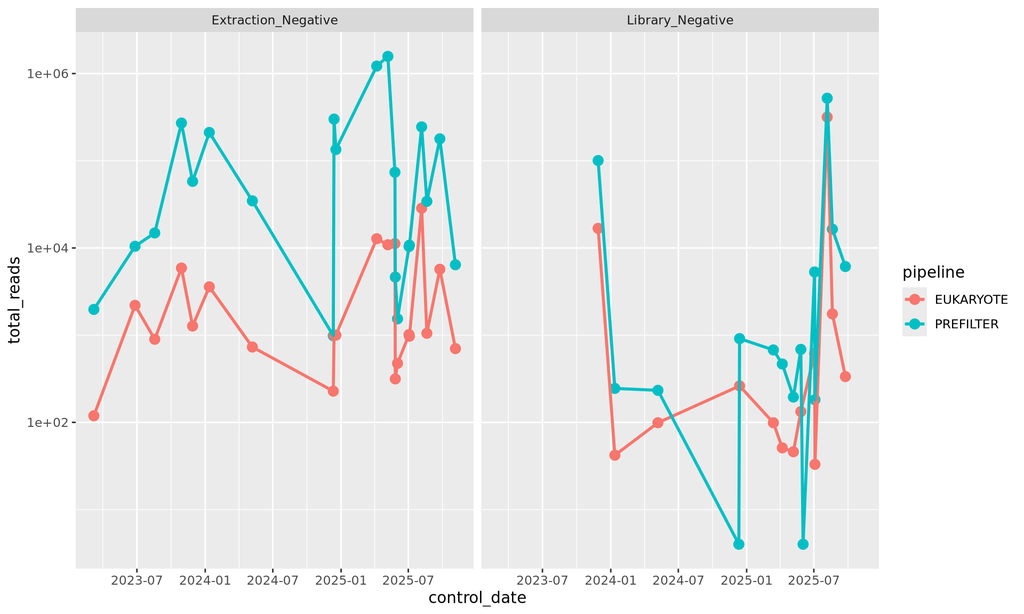

```r
p <- df %>%
  filter(rank == "order" & control_type != "Extraction_Positive") %>%
  group_by(control_date, pipeline,control_type) %>%
  summarise(total_reads = sum(nreads), .groups = "drop") %>%
  ggplot(aes(control_date, total_reads, colour = pipeline)) +
  geom_point(size = 3) +
  geom_line(linewidth = 1) +
  scale_y_log10() +
  facet_wrap(~control_type)
ggsave(paste0("plots/", datetime, "/total_contamination_over_time.png"), plot = p, width = 10, height = 6)
print(p)
```

# Kingdom level composition over time

To understand how contamination composition changes through time, taxa are grouped into broad biological kingdoms and their relative abundance is visualized. For each control date, the proportion of reads assigned to each kingdom is shown as a stacked area plot. The values are normalized so that each time point sums to one, highlighting shifts in composition rather than absolute abundance. Rug marks along the bottom of the plot indicate the distribution of individual control libraries in time.

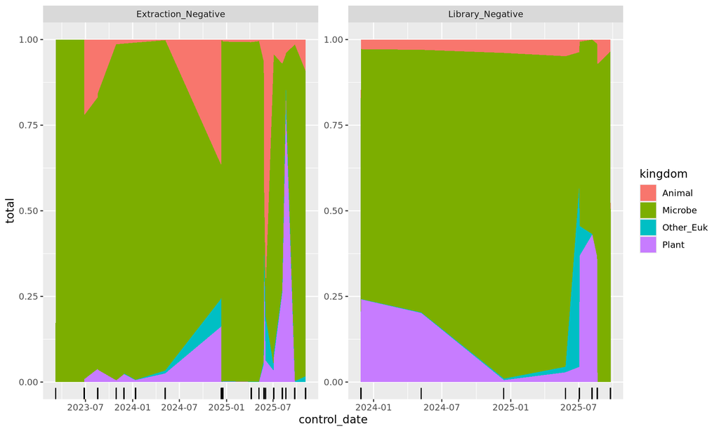

```r
p <- df_filt %>%
  mutate(
    kingdom = case_when(
      pipeline == "PREFILTER" ~ "Microbe",
      grepl("Metazoa", taxa_path) ~ "Animal",
      grepl("Viridiplantae", taxa_path) ~ "Plant",
      TRUE ~ "Other_Euk"
    )
  ) %>%
  group_by(control_date, kingdom, control_type) %>%
  summarise(total = sum(nreads), .groups = "drop") %>%
  ggplot(aes(control_date, total, fill = kingdom)) +
  geom_area(position = "fill") +
  facet_wrap(~control_type,scales="free") +
  geom_rug(data = df_filt, aes(x = control_date), sides = "b", inherit.aes = FALSE)
ggsave(paste0("plots/", datetime, "/kingdom_composition_over_time.png"), plot = p, width = 10, height = 6)
print(p)
```

# Heatmaps for individual taxa over time

## Plant genus-level contamination over time

This heatmap shows plant taxa detected in control libraries using the EUKARYOTE pipeline.

Each row corresponds to a plant genus and each column corresponds to a control date. Color intensity represents the logarithm of the number of reads assigned to that genus.

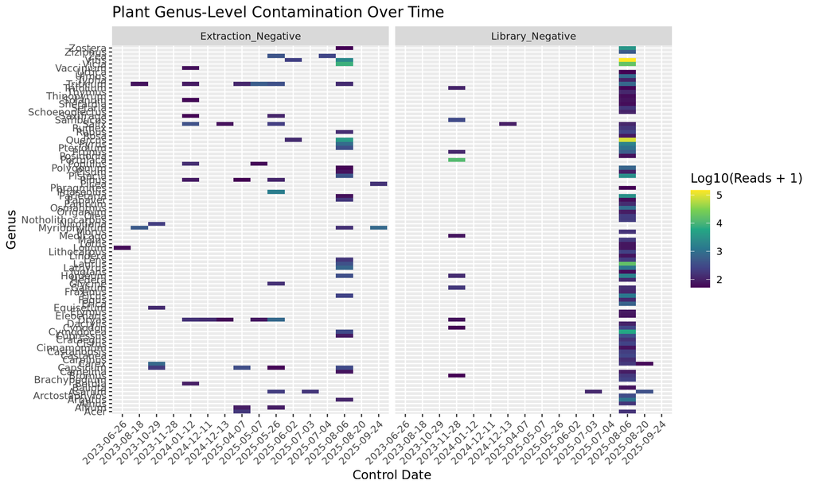

```r
p <- df_filt %>% filter(kingdom == "Plant" & nreads > 49 & pipeline == "EUKARYOTE" ) %>%
  group_by(control_date, name,control_type) %>%
  summarise(nreads = sum(nreads), .groups = "drop") %>%
  ggplot(aes(as.factor(control_date), name, fill = log10(nreads + 1))) +
  geom_tile() +
  facet_wrap(~control_type) +
  scale_fill_viridis_c() +
  labs(x = "Control Date", y = "Genus", fill = "Log10(Reads + 1)") +
  ggtitle("Plant Genus-Level Contamination Over Time") +
  theme(axis.text.x = element_text(angle = 45, hjust = 1))
ggsave(paste0("plots/", datetime, "/plant_genus_heatmap.png"), plot = p, width = 10, height = 6)
print(p)
```

## Animal genus-level contamination over time

This heatmap displays animal taxa detected in control libraries. Similar to the plant heatmap, each tile shows the abundance of reads assigned to a particular genus at a given control date.

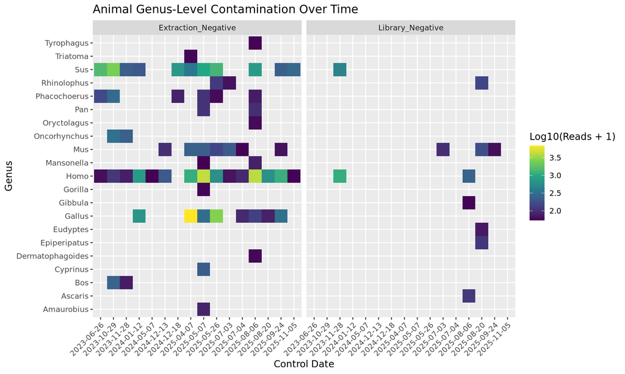

```r
p <- df_filt %>% filter(kingdom == "Animal" & nreads > 49 & pipeline == "EUKARYOTE" ) %>%
  group_by(control_date, name,control_type) %>%
  summarise(nreads = sum(nreads), .groups = "drop") %>%
  ggplot(aes(as.factor(control_date), name, fill = log10(nreads + 1))) +
  geom_tile() +
  facet_wrap(~control_type) +
  scale_fill_viridis_c() +
  labs(x = "Control Date", y = "Genus", fill = "Log10(Reads + 1)") +
  ggtitle("Animal Genus-Level Contamination Over Time") +
  theme(axis.text.x = element_text(angle = 45, hjust = 1))
ggsave(paste0("plots/", datetime, "/animal_genus_heatmap.png"), plot = p, width = 10, height = 6)
print(p)
```

## Other eukaryotic contamination

This heatmap shows eukaryotic taxa that are neither classified as plants nor animals. These may include fungi, protists, or other eukaryotic microorganisms.

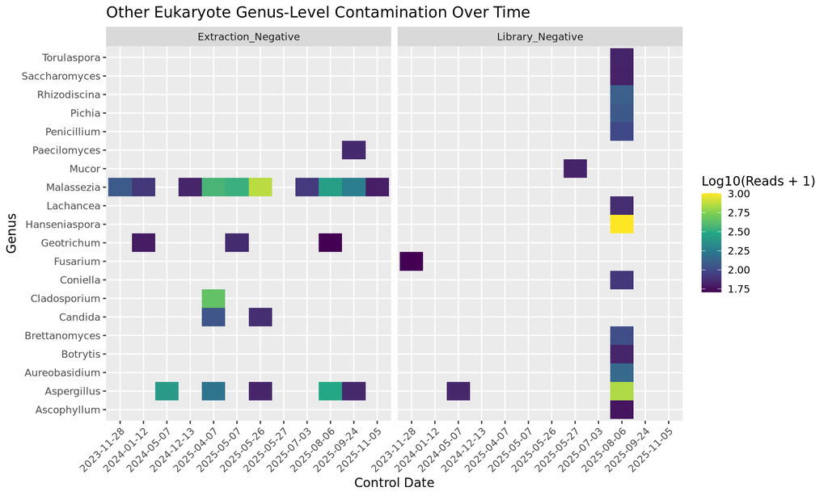

```r
p <- df_filt %>% filter(kingdom == "Other" & nreads > 49 & pipeline == "EUKARYOTE" ) %>%
  group_by(control_date, name,control_type) %>%
  summarise(nreads = sum(nreads), .groups = "drop") %>%
  ggplot(aes(as.factor(control_date), name, fill = log10(nreads + 1))) +
  geom_tile() +
  facet_wrap(~control_type) +
  scale_fill_viridis_c() +
  labs(x = "Control Date", y = "Genus", fill = "Log10(Reads + 1)") +
  ggtitle("Other Eukaryote Genus-Level Contamination Over Time") +
  theme(axis.text.x = element_text(angle = 45, hjust = 1))
ggsave(paste0("plots/", datetime, "/other_eukaryote_genus_heatmap.png"), plot = p, width = 10, height = 6)
print(p)
```

## Bacterial contamination

Bacterial assignments are far more numerous and diverse than eukaryotic taxa. To keep the visualization interpretable, only the top 20 bacterial orders by total read count are displayed.

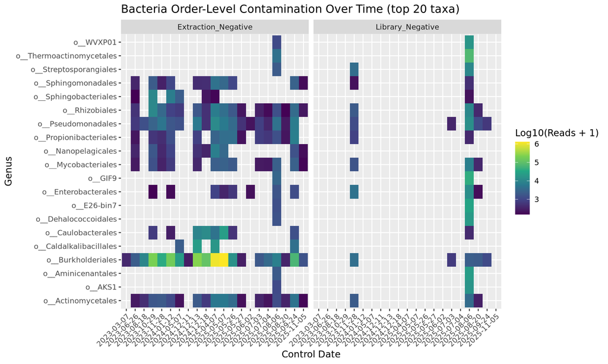

```r
top_orders <- df_filt %>% filter(kingdom == "Microbe") %>%
  group_by(name) %>%
  summarise(total_reads = sum(nreads), .groups = "drop") %>%
  arrange(desc(total_reads)) %>%
  head(20) %>%
  pull(name)

p <- df_filt %>%
  filter(name %in% top_orders) %>%
  group_by(control_date, name, control_type) %>%
  summarise(nreads = sum(nreads), .groups = "drop") %>%
  ggplot(aes(as.factor(control_date), name, fill = log10(nreads + 1))) +
  geom_tile() +
  facet_wrap(~control_type) +
  scale_fill_viridis_c() +
  labs(x = "Control Date", y = "Genus", fill = "Log10(Reads + 1)") +
  ggtitle("Bacteria Order-Level Contamination Over Time (top 20 taxa)") +
  theme(axis.text.x = element_text(angle = 45, hjust = 1))
ggsave(paste0("plots/", datetime, "/bacteria_order_heatmap.png"), plot = p, width = 10, height = 6)
print(p)
```

# Distribution of reads per kingdom over time

The distribution of read counts for each kingdom is summarized through time using boxplots. Each box represents a monthly distribution of read counts across control libraries.

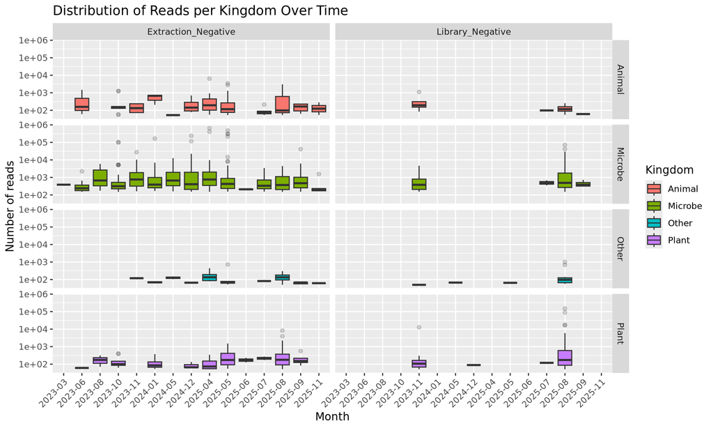

```r
df_plot <- df_filt %>%
  mutate(month = format(control_date, "%Y-%m"))

p <- ggplot(df_plot, aes(month, nreads, fill = kingdom)) +
  geom_boxplot(outlier.alpha = 0.2) +
  facet_grid(
  kingdom ~ control_type  ) +
  scale_y_log10() +
  labs(
    x = "Month",
    y = "Number of reads",
    fill = "Kingdom",
    title = "Distribution of Reads per Kingdom Over Time"
  ) +
  theme(axis.text.x = element_text(angle = 45, hjust = 1))
ggsave(paste0("plots/", datetime, "/kingdom_reads_over_time.png"), plot = p, width = 10, height = 6)
print(p)
```

# Libraries with the highest contamination levels

This plot highlights the control libraries with the highest total number of contaminant reads. Libraries are ranked within each control type, and bars are colored according to the biological kingdom contributing the reads.

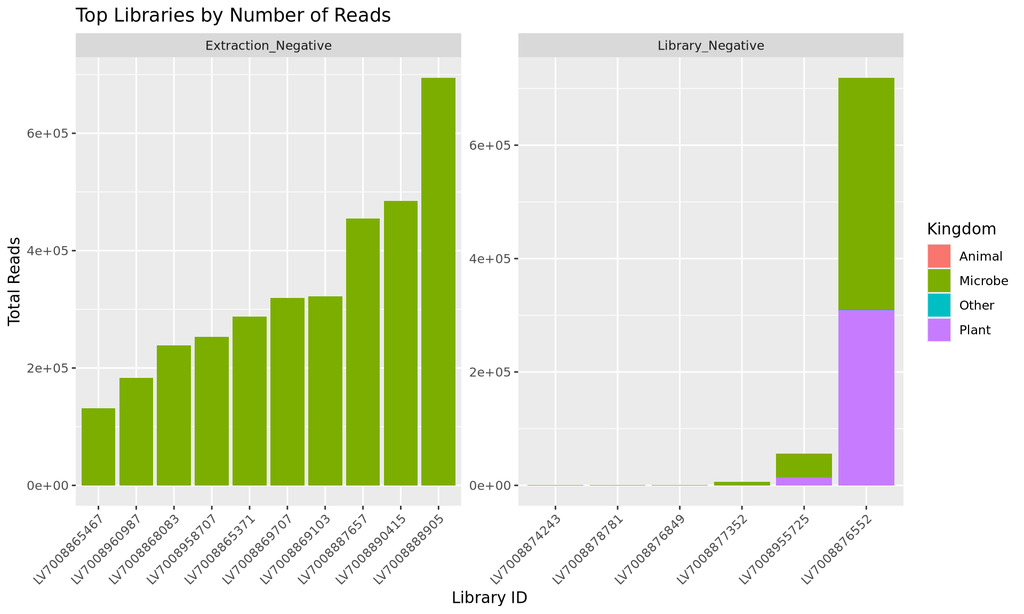

```r
top_libraries <- df_filt %>%
  group_by(library_id, kingdom, control_type) %>%
  summarise(total_reads = sum(nreads), .groups = "drop") %>%
  arrange(desc(total_reads)) %>%
  group_by(control_type) %>%
  slice_head(n = 10) %>%
  ungroup()

p <- top_libraries %>%
  ggplot(aes(x = reorder(library_id, total_reads), y = total_reads, fill = kingdom)) +
  geom_bar(stat = "identity") +
  labs(x = "Library ID", y = "Total Reads", fill = "Kingdom", title = "Top Libraries by Number of Reads") +
  facet_wrap(~control_type, scales="free") +
  theme(axis.text.x = element_text(angle = 45, hjust = 1))

ggsave(paste0("plots/", datetime, "/top_libraries_reads.png"), plot = p, width = 10, height = 6)
print(p)
```

# Ordination of contamination profiles using PCoA

To explore similarities between control libraries, we perform a Principal Coordinates Analysis (PCoA) based on Bray-Curtis distances of relative taxon abundances.

Each point represents a control library, positioned according to the similarity of its contamination profile. Libraries that cluster together share similar taxonomic compositions.

Points are colored by control date and shaped by control type to visualize temporal patterns or systematic differences between control categories.

## Ordination of eukaryotic contamination profiles

This PCoA is based on the relative abundance of eukaryotic taxa detected by the EUKARYOTE pipeline.

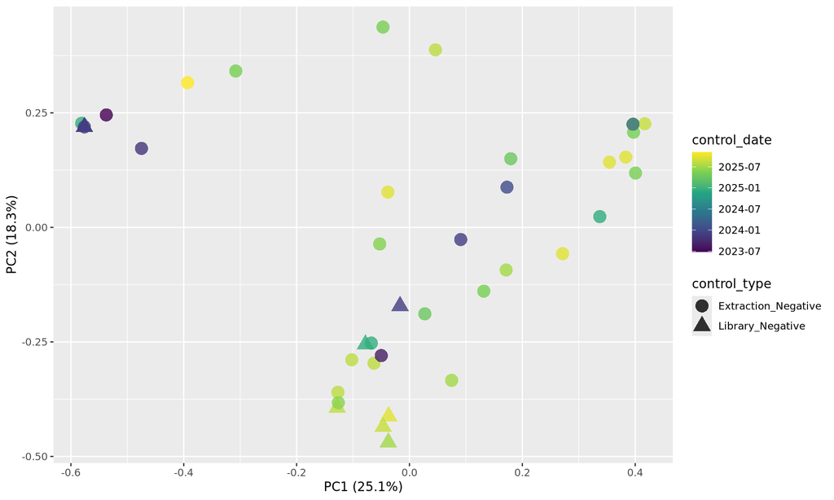

```r
mat_df <- df_filt %>%
  filter(kingdom != "Other", pipeline == "EUKARYOTE") %>%
  group_by(library_id, name) %>%
  summarise(nreads = sum(nreads), .groups = "drop") %>%
  pivot_wider(
    names_from = name,
    values_from = nreads,
    values_fill = 0
  )

library_ids <- mat_df$library_id

mat <- mat_df %>%
  select(-library_id) %>%
  as.matrix()

rownames(mat) <- library_ids

mat_rel <- sweep(mat, 1, rowSums(mat), "/")
dist_mat <- vegdist(mat_rel, method = "bray")
pcoa_res <- cmdscale(dist_mat, eig = TRUE, k = 2)
scores <- as.data.frame(pcoa_res$points)
colnames(scores) <- c("PC1", "PC2")
scores$library_id <- rownames(scores)
meta <- df_filt %>%
  distinct(library_id, control_type, control_date)

plot_df <- dplyr::left_join(scores, meta, by = "library_id")
var_explained <- pcoa_res$eig / sum(pcoa_res$eig)

xlab <- paste0("PC1 (", round(var_explained[1] * 100, 1), "%)")
ylab <- paste0("PC2 (", round(var_explained[2] * 100, 1), "%)")

p <- ggplot(plot_df, aes(PC1, PC2, colour = control_date, shape = control_type)) +
  geom_point(size = 5, alpha = 0.8) +
  labs(x = xlab, y = ylab) +
  scale_colour_viridis_c(trans = "date")
ggsave(paste0("plots/", datetime, "/pcoa_eukaryotes.png"), plot = p, width = 10, height = 6)
print(p)
```

## Ordination of bacterial contamination profiles

We now do the same ordination analysis but for bacterial taxa detected by the PREFILTER pipeline.

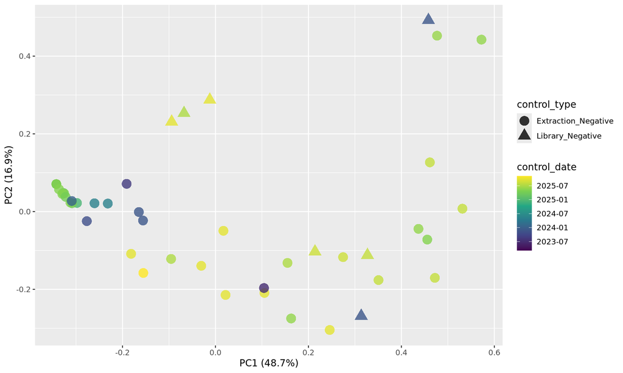

```r
mat_df <- df_filt %>%
  filter(kingdom == "Microbe", pipeline == "PREFILTER") %>%
  group_by(library_id, name) %>%
  summarise(nreads = sum(nreads), .groups = "drop") %>%
  pivot_wider(
    names_from = name,
    values_from = nreads,
    values_fill = 0
  )

library_ids <- mat_df$library_id

mat <- mat_df %>%
  select(-library_id) %>%
  as.matrix()

rownames(mat) <- library_ids

mat_rel <- sweep(mat, 1, rowSums(mat), "/")
dist_mat <- vegdist(mat_rel, method = "bray")
pcoa_res <- cmdscale(dist_mat, eig = TRUE, k = 2)
scores <- as.data.frame(pcoa_res$points)
colnames(scores) <- c("PC1", "PC2")
scores$library_id <- rownames(scores)
meta <- df_filt %>%
  distinct(library_id, control_type, control_date)

plot_df <- dplyr::left_join(scores, meta, by = "library_id")
var_explained <- pcoa_res$eig / sum(pcoa_res$eig)

xlab <- paste0("PC1 (", round(var_explained[1] * 100, 1), "%)")
ylab <- paste0("PC2 (", round(var_explained[2] * 100, 1), "%)")

p <- ggplot(plot_df, aes(PC1, PC2, colour = control_date, shape = control_type)) +
  geom_point(size = 5, alpha = 0.8) +
  labs(x = xlab, y = ylab) +
  scale_colour_viridis_c(trans = "date")
ggsave(paste0("plots/", datetime, "/pcoa_bacteria.png"), plot = p, width = 10, height = 6)
print(p)
```

# DNA damage patterns of dominant taxa

Ancient DNA damage patterns can help distinguish genuine ancient molecules from modern contamination. The parameter A represents the estimated damage level of the first position at the 5’ end, corrected for background substitution levels.

This plot shows the damage estimates for the most abundant taxa in each kingdom. Each point represents a taxon detected in a control library, with point size reflecting the number of reads.

Comparing damage levels across taxa and control types can help identify whether certain contaminants display patterns consistent with modern or degraded DNA.

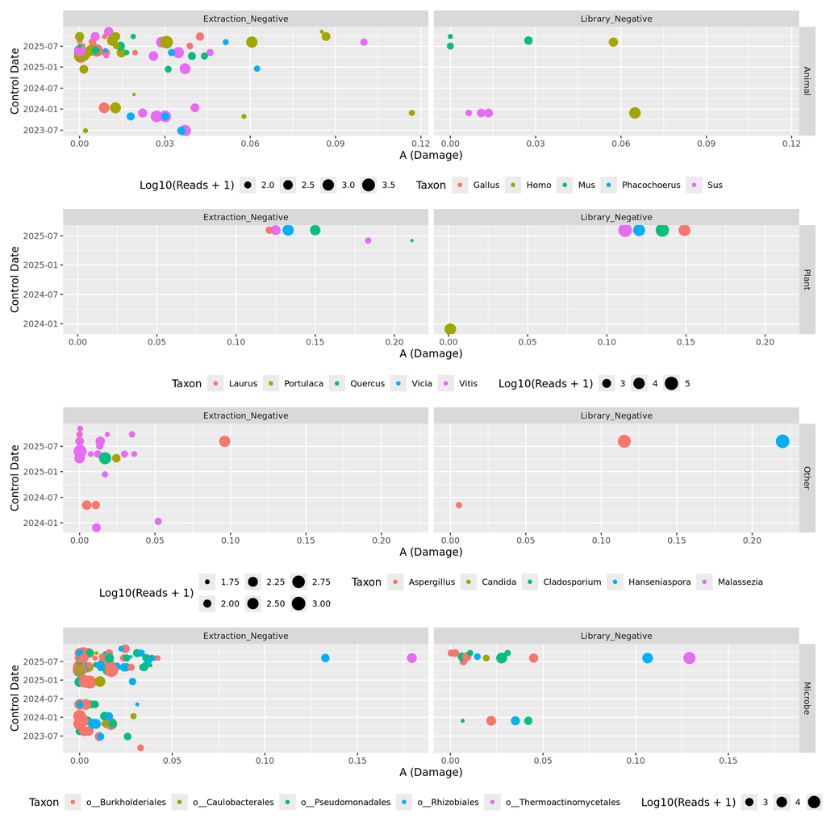

```r
# top 20 taxa per kingdom
top_taxa <- df_filt %>%
  group_by(kingdom,name) %>%
  summarise(total_reads = sum(nreads), .groups = "drop") %>%
  arrange(desc(total_reads)) %>%
  group_by(kingdom) %>%
  slice_head(n = 5) %>%
  ungroup() %>%
  pull(name)

p_animal <- df_filt %>%
  filter(name %in% top_taxa & kingdom == "Animal") %>%
  ggplot(aes(y = control_date, x = A, color = name, size = log10(nreads + 1))) +
  geom_point() +
  facet_grid(kingdom ~ control_type) +
  labs(x = "A (Damage)", y = "Control Date", color = "Taxon", size = "Log10(Reads + 1)") +
  theme(legend.position = "bottom")
p_other <- df_filt %>%
  filter(name %in% top_taxa & kingdom == "Other") %>%
  ggplot(aes(y = control_date, x = A, color = name, size = log10(nreads + 1))) +
  geom_point() +
  facet_grid(kingdom ~ control_type) +
  labs(x = "A (Damage)", y = "Control Date", color = "Taxon", size = "Log10(Reads + 1)") +
  theme(legend.position = "bottom")
p_plant <- df_filt %>%
  filter(name %in% top_taxa & kingdom == "Plant") %>%
  ggplot(aes(y = control_date, x = A, color = name, size = log10(nreads + 1))) +
  geom_point() +
  facet_grid(kingdom ~ control_type) +
  labs(x = "A (Damage)", y = "Control Date", color = "Taxon", size = "Log10(Reads + 1)") +
  theme(legend.position = "bottom")
p_mic <- df_filt %>%
  filter(name %in% top_taxa & kingdom == "Microbe") %>%
  ggplot(aes(y = control_date, x = A, color = name, size = log10(nreads + 1))) +
  geom_point() +
  facet_grid(kingdom ~ control_type) +
  labs(x = "A (Damage)", y = "Control Date", color = "Taxon", size = "Log10(Reads + 1)") +
  theme(legend.position = "bottom")
p <- p_animal / p_plant / p_other / p_mic
ggsave(paste0("plots/", datetime, "/top_taxa_barplot.png"), plot = p, width = 10, height = 6)
print(p)
```